# Han_Fengyang_HW_06

## CMPINF 2100: Homework 06

## Assigned: Tuesday of Week 06 at 11:00PM

## DUE: Tuesday of Week 07 at 11:59PM

## Overview

This assignment is open ended similar to the previous assignment. You will work with the SAME three data sets as in Homework 05. You already identified the BASIC and ESSENTIAL information for the variables (columns) in the three data sets. You calculated important summary statistics, and even examined if summary statistics changed based on different grouping variables. The Homework 05 exploration results were displayed within DataFrames and/or text. You printed results to the screen and provided Markdown text to accompany the table-like results.

You will repeat many of the same exploration steps from Homework 05, but this time you will **visually** explore the data! You will graphically display the exploratory results using plots/figures. You will explore **marginal** behavior by focusing on individual variables. Then you will explore **combinations** and **relationships** between 2 variables. The figures associated with studying **relationships** will graphically answer the SPLIT-APPLY-COMBINE related questions from the previous assignment. Certain tasks allow you to choose between Pandas plotting methods and Seaborn functions, while others state you must use Seaborn to create the figures.

The last question requires you to start visually exploring **marginal** behavior associated with one of the final projects of your choosing.

**You must use the 3 data sets provided in Homework 05 Canvas assignment page. You may use the same data you previously downloaded, or redownload the CSV files to the appropriate directory on your computer.**

## Required tasks for Problem 01 through 03

For each of the 3 assigned data sets you must create plots/figures/charts to explore **marginal** behavior. You must therefore perform the following tasks:

- Create BAR CHARTS to visually show the counts for the number of rows per unique value for NON-NUMERIC columns
  - You may use Pandas or Seaborn to create the bar charts
- Create HISTOGRAMS to visually show the DISTRIBUTION of NUMERIC columns
  - You may use Pandas or Seaborn to create the histogram
- **IMPORTANT:** You **MUST** visually explore the counts of NUMERIC columns that have less than 20 unique values as if they are NON-NUMERIC columns
- **IMPORTANT:** After creating BAR CHARTS and HISTOGRAMS answer the following:
  - Do the categories of the NON-NUMERIC columns have similar counts?
  - Do the histograms of the NUMERIC columns look roughly like bell curves?

For each of the 3 assigned data sets you must create plots/figures/charts to explore **combinations** between 2 NON-NUMERIC columns. You must therefore perform the following tasks:

- Create DODGED bar charts to visually show the COUNTS for COMBINATIONS between 2 NON-NUMERIC columns
  - You **MUST** create the DODGED bar chart using Seaborn
- Create HEAT MAPS to visually show the COUNTS for COMBINATIONS between 2 NON-NUMERIC columns
  - You **MUST** create the HEAT MAP using Seaborn
  - The HEAT MAP **MUST** be annotated with count displayed as TEXT
- **IMPORTANT:** You **MUST** treat NUMERIC columns that have less than 20 unique values as if they are NON-NUMERIC columns
- **IMPORTANT:** After creating the DODGED bar charts and HEAT MAPS answer the following:
  - Are there combinations between the 2 variables NOT present in the data?
  - Which plot type was it easier to identify combinations that were NOT present?

For each of the 3 assigned data sets you must create plots/figures/charts to explore **relationships** between CATEGORICAL and CONTINUOUS variables. You must therefore explore the relationship between 1 NON-NUMERIC column and 1 NUMERIC column. You must perform the following tasks:

- Create CONDITIONAL KDE plots to show the conditional distribution of the NUMERIC column CONDITIONED ON (or GROUPED BY) the NON-NUMERIC column
  - You **MUST** create the CONDITIONAL KDE plot using Seaborn with the NON-NUMERIC column associated with the KDE COLOR
  - You **MUST** remove the SAMPLE SIZE issue with the CONDITIONAL KDE plot
- Create BOXPLOTS to show if the SUMMARY STATISTICS of the NUMERIC column CHANGE across the CATEGORIES of the NON-NUMERIC column
  - You **MUST** create the BOXPLOT using Seaborn
- Create POINT PLOTS to show if the CONDITIONAL MEAN of the NUMERIC columns CHANGE across the CATEGORIES of the NON-NUMERIC column
  - You **MUST** create the POINT PLOT using Seaborn
- **IMPORTANT:** You **MUST** treat NUMERIC columns that have less than 20 unique values as if they are NON-NUMERIC columns
- **IMPORTANT:** After creating the figures you must answer the following:
  - Does the distributional SHAPE of a NUMERIC column appear to be different across the CATEGORIES of the NON-NUMERIC column?
  - Does the MEDIAN of the NUMERIC column appear to be different across the CATEGORIES of the NON-NUMERIC column?
  - Does the VARIATION of the NUMERIC column appear to be different across the CATEGORIES of the NON-NUMERIC column?
  - Are you confident that the MEAN of the NUMERIC column CHANGES across the CATEGORIES of the NON-NUMERIC column?

### Collaborators

Shiyi Wang

## Problem 00

You will work with the NumPy, Pandas, matplotlib.pyplot, and Seaborn modules in this assignment.

Import NumPy, Pandas, matplotlib.pyplot, and Seaborn using their commonly accepted aliases.

#### 00) - SOLUTION

```python
###
import numpy as np
import pandas as pd
import matplotlib.pyplot as plt
import seaborn as sns
```

## Problem 01

Read in the `hw05_prob_01.csv` CSV file and assign it to the `df01` object.

Visually explore the `df01` object following **ALL** required actions listed previously.

You must add more code cells and markdown cells to complete this problem.

#### 01) - SOLUTION

```python
###
df01 = pd.read_csv('hw05_prob_01.csv')
df01.info()
```

```
<class 'pandas.core.frame.DataFrame'>
RangeIndex: 130 entries, 0 to 129
Data columns (total 4 columns):
 #   Column  Non-Null Count  Dtype
---  ------  --------------  -----
 0   A       130 non-null    object
 1   B       130 non-null    object
 2   C       130 non-null    object
 3   x       130 non-null    float64
dtypes: float64(1), object(3)
memory usage: 4.2+ KB
```

```python
df01.nunique()
```

```
A      2
B      2
C      2
x    130
dtype: int64
```

```python
df01.isna().sum()
```

```
A    0
B    0
C    0
x    0
dtype: int64
```

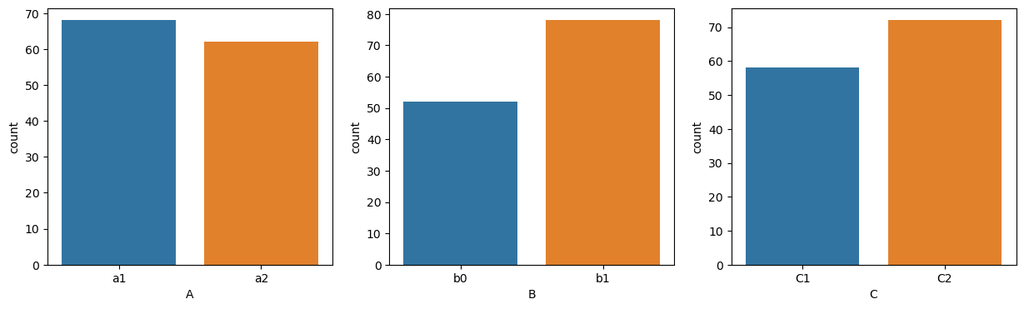

```python
# bar plot for A B C
fig,ax = plt.subplots(1,3,figsize=(15,4))

sns.countplot(data = df01, x = 'A', ax = ax[0])
sns.countplot(data = df01, x = 'B', ax = ax[1])
sns.countplot(data = df01, x = 'C', ax = ax[2])

plt.show()
```

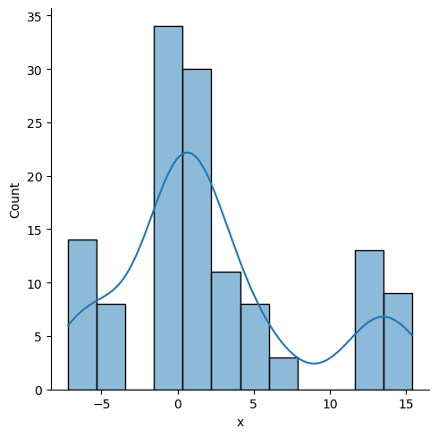

```python
# HISTOGRAMS for NUMERIC COLUNMS
sns.displot(data=df01, x='x', kind = "hist", kde=True)
plt.show()
```

### Conclusion 1

The categories of the NON_NUMERIC columns : column A has similar counts, but column B and C have different counts.

The histograms of the NUMERIC columns don't look like bell curves.

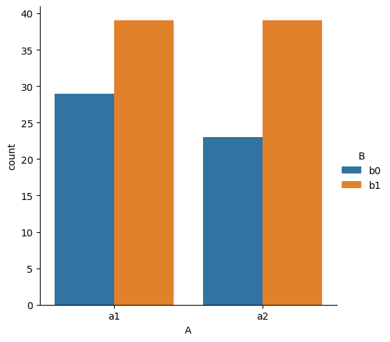

```python
## DODGED BAR PLOT between 2 NON-NUMERIC COLUMNS
sns.catplot(data = df01, x = 'A', hue = 'B', kind = "count")
plt.show()
```

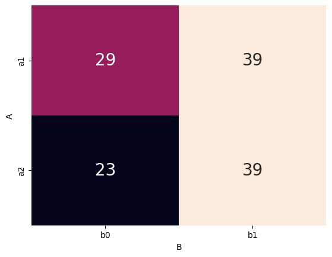

```python
## HEAT MAP between 2 NON-NUMERIC COLUMNS
fig,ax = plt.subplots()

sns.heatmap(pd.crosstab(df01['A'], df01['B']), ax=ax,
            annot = True,
            annot_kws = {'size': 20},
            fmt = 'd',
            cbar = False)

plt.show()
```

### Conclusion 2

No, there are no combinations between the 2 variables NOT present in the data.

HEAT MAP is easier to identify combinations that were NOT present.

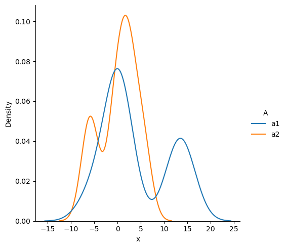

```python
## Conditional KDE PLOT on NUMERIC COLUMN, conditioned on NON-NUMERIC COLUMN

sns.displot(data = df01, x = 'x', hue = 'A', kind = "kde",
            common_norm = False)

plt.show()
```

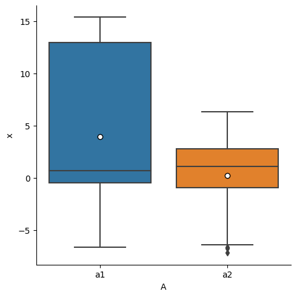

```python
## Boxplot on NUMERIC COLUMN
sns.catplot(data = df01, x = 'A', y = 'x', kind = "box",
            showmeans = True,
            meanprops={'marker':'o','markerfacecolor':'white','markeredgecolor':'black'})

plt.show()
```

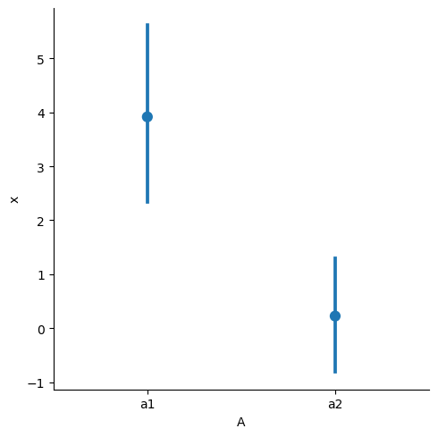

```python
## POINT PLOT on NUMERIC COLUMN
sns.catplot(data = df01, x = 'A', y = 'x', kind = "point",
            join = False)

plt.show()
```

### Conclusion 3

1. Yes, they are different.
2. They have similar median
3. They have different variation.
4. Yes, I am confident that the MEAN value CHANGES.

## Problem 02

Read in the `hw05_prob_02.csv` CSV file and assign it to the `df02` object.

Visually explore the `df02` object following **ALL** required actions listed previously.

You must add more code cells and markdown cells to complete this problem.

#### 02) - SOLUTION

```python
###
df02 = pd.read_csv('hw05_prob_02.csv')
df02.info()
```

```
<class 'pandas.core.frame.DataFrame'>
RangeIndex: 368 entries, 0 to 367
Data columns (total 4 columns):
 #   Column  Non-Null Count  Dtype
---  ------  --------------  -----
 0   x       368 non-null    float64
 1   y       352 non-null    float64
 2   A       347 non-null    float64
 3   G       368 non-null    int64
dtypes: float64(3), int64(1)
memory usage: 11.6 KB
```

```python
df02.nunique()
```

```
x    368
y    352
A      2
G     14
dtype: int64
```

```python
df02.isna().sum()
```

```
x     0
y    16
A    21
G     0
dtype: int64
```

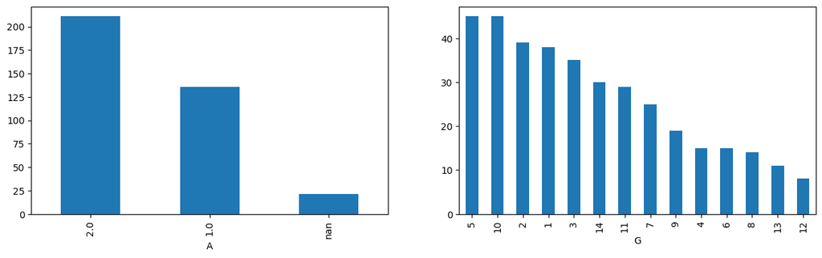

```python
## Since columns A has less than 20 unique values, we can use bar plot as if they are NON_NUMERIC columns
fig, ax = plt.subplots(1, 2, figsize=(15,4))

df02.A.value_counts(dropna=False).plot( kind='bar', ax=ax[0] )
df02.G.value_counts(dropna=False).plot( kind='bar', ax=ax[1] )

plt.show()
```

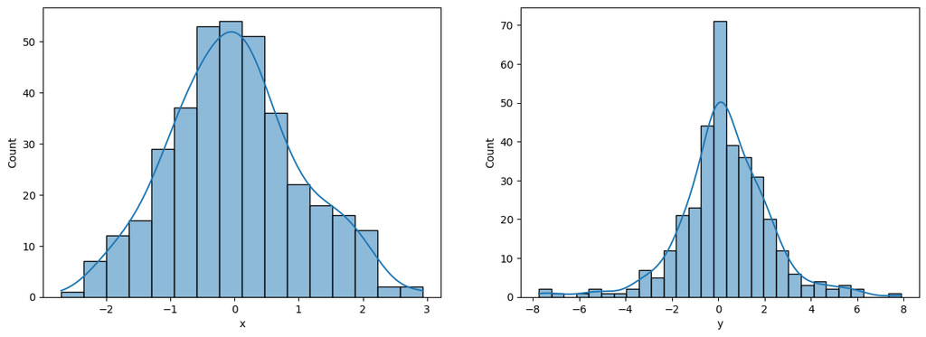

```python
# HISTOGRAMS for NUMERIC COLUNMS
fig,ax = plt.subplots(1,2,figsize=(15,5))

sns.histplot(data=df02, x='x', ax = ax[0],kde=True)
sns.histplot(data=df02, x='y', ax = ax[1],kde=True)

plt.show()
```

### Conclusion 1

The categories of the NON_NUMERIC columns : column A and G has different counts.

The histograms of the NUMERIC columns: column x and y look like bell curves.

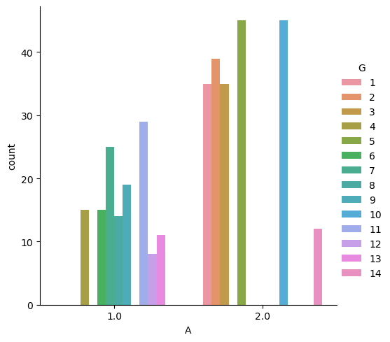

```python
## DODGED BAR PLOT between 2 NON-NUMERIC COLUMNS

sns.catplot( data = df02, x='A', hue='G', kind='count')

plt.show()
```

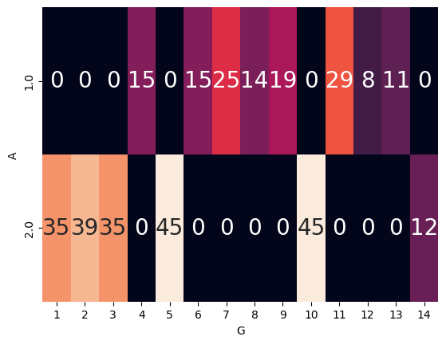

```python
fig, ax = plt.subplots()

sns.heatmap(pd.crosstab(df02['A'], df02['G']), ax=ax,
            annot = True,
            annot_kws = {'size': 20},
            fmt = 'd',
            cbar = False)

plt.show()
```

### Conclusion 2

There are several combinations between the 2 variables are NOT present in the data.

HEAT MAP is easier to identify combinations that were NOT present.

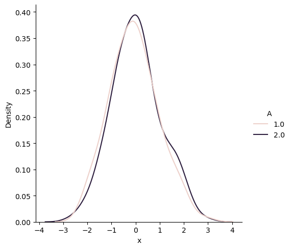

```python
## Conditional KDE PLOT on NUMERIC COLUMN, conditioned on NON-NUMERIC COLUMN
sns.displot(data = df02, x = 'x', hue = 'A', kind = "kde",
            common_norm = False)

plt.show()
```

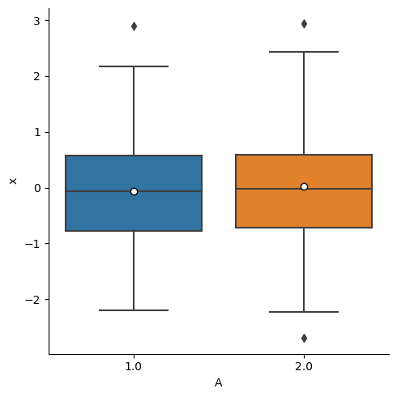

```python
## Boxplot on NUMERIC COLUMN
sns.catplot(data = df02, x = 'A', y = 'x', kind = "box",
            showmeans = True,
            meanprops={'marker':'o','markerfacecolor':'white','markeredgecolor':'black'})

plt.show()
```

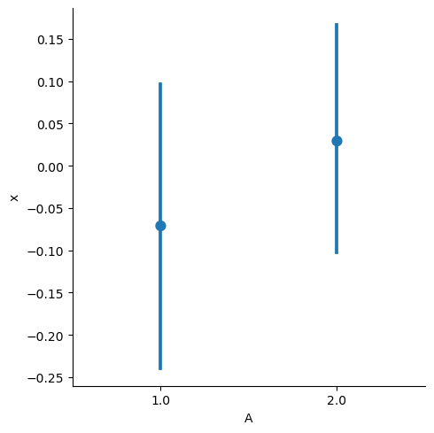

```python
## POINT PLOT on NUMERIC COLUMN
sns.catplot(data = df02, x = 'A', y = 'x', kind = "point",
            join = False)

plt.show()
```

### Conclusion 3

1. No, they are not different.
2. They have similar medians.
3. They have similar variations.
4. No, I am not confident that the MEAN value CHANGES.

## Problem 03

Read in the `hw05_prob_03.csv` CSV file and assign it to the `df03` object.

Visually explore the `df03` object following **ALL** required actions listed previously.

You must add more code cells and markdown cells to complete this problem.

#### 03) - SOLUTION

```python
###
df03 = pd.read_csv('hw05_prob_03.csv')
df03.info()
```

```
<class 'pandas.core.frame.DataFrame'>
RangeIndex: 1407 entries, 0 to 1406
Data columns (total 3 columns):
 #   Column  Non-Null Count  Dtype
---  ------  --------------  -----
 0   obs_id  1407 non-null   int64
 1   key     1407 non-null   object
 2   value   1379 non-null   float64
dtypes: float64(1), int64(1), object(1)
memory usage: 33.1+ KB
```

```python
df03.nunique()
```

```
obs_id     201
key          7
value     1379
dtype: int64
```

```python
df03.isna().sum()
```

```
obs_id     0
key        0
value     28
dtype: int64
```

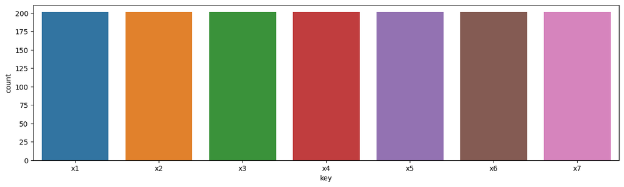

```python
## BAR CHART for key
fig,ax = plt.subplots(figsize=(15,4))
sns.countplot(data = df03, x = 'key', ax = ax)
plt.show()
```

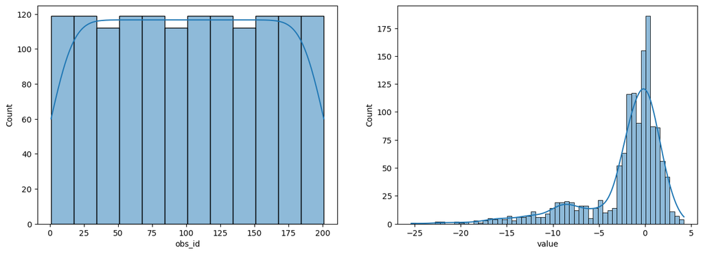

```python
# HISTOGRAMS for NUMERIC COLUNMS
fig,ax = plt.subplots(1,2,figsize=(15,5))

sns.histplot(data=df03, x='obs_id', ax = ax[0],kde=True)
sns.histplot(data=df03, x='value', ax = ax[1],kde=True)
```

### Conclusion 1

The histograms of the NUMERIC columns: column obs_id and value don't look like bell curves.

```python
## DODGED BAR PLOT between 2 NON-NUMERIC COLUMNS
## There is only column key, skip
```

### Conclusion 2

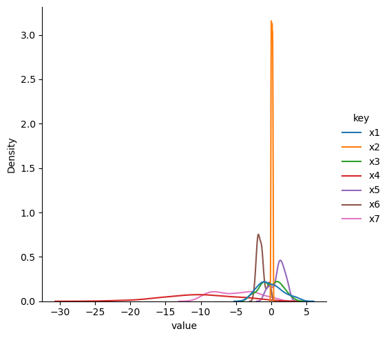

```python
## Conditional KDE PLOT on NUMERIC COLUMN, conditioned on NON-NUMERIC COLUMN
sns.displot(data = df03, x = 'value', hue = 'key', kind = "kde",
            common_norm = False)

plt.show()
```

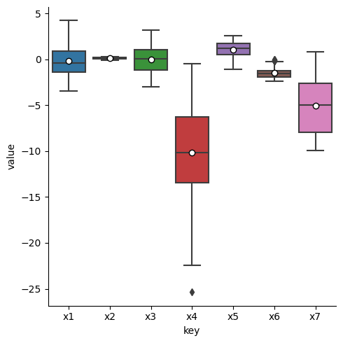

```python
## Boxplot on NUMERIC COLUMN
sns.catplot(data = df03, x = 'key', y = 'value', kind = "box",
            showmeans = True,
            meanprops={'marker':'o','markerfacecolor':'white','markeredgecolor':'black'})

plt.show()
```

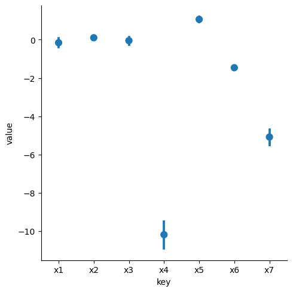

```python
## POINT PLOT on NUMERIC COLUMN
sns.catplot(data = df03, x = 'key', y = 'value', kind = "point",
            join = False)

plt.show()
```

### Conclusion 3

1. Yes, they are different.
2. They are different.
3. They are different.
4. Yes, I am confident that the MEAN value CHANGES.

## Problem 04

You must download the data associated with one of the Final Projects from the Canvas site. Save the file(s) in the same directory as this Jupyter notebook.

Read in the data associated with one of the Final Projects. You must start to visually explore the variables in the Project data. However, you do NOT need to explore ALL variables in this assignment.

You **MUST** visually explore the **marginal** behavior of at least 6 variables. You must use the plot type appropriate for the data type and number of unique values for each variable.

#### 04) - SOLUTION

```python
###
df_pj = pd.read_csv('./trial_inputs.csv')
df_pj.info()
```

```
<class 'pandas.core.frame.DataFrame'>
RangeIndex: 240 entries, 0 to 239
Data columns (total 7 columns):
 #   Column    Non-Null Count  Dtype
---  ------    --------------  -----
 0   trial_id  240 non-null    int64
 1   x1        240 non-null    int64
 2   x2        240 non-null    int64
 3   x3        240 non-null    int64
 4   x4        240 non-null    int64
 5   x5        240 non-null    int64
 6   x6        240 non-null    object
dtypes: int64(6), object(1)
memory usage: 13.3+ KB
```

```python
df_pj.nunique()
```

```
trial_id    240
x1            3
x2            3
x3            2
x4            2
x5            3
x6            4
dtype: int64
```

```python
df_pj.isna().sum()
```

```
trial_id    0
x1          0
x2          0
x3          0
x4          0
x5          0
x6          0
dtype: int64
```

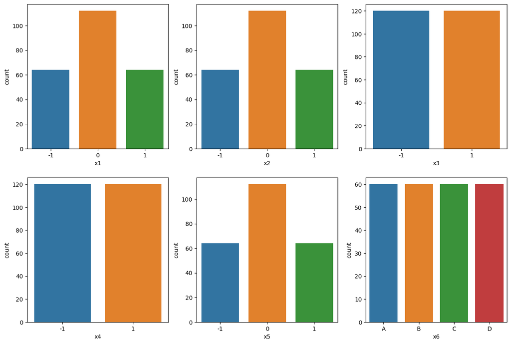

```python
## # Since x1-x6 has less than 20 unique values, we can use bar plot as if they are NON_NUMERIC columns in df_pj
fig,ax = plt.subplots(2,3,figsize=(15,10))

sns.countplot(data = df_pj, x = 'x1', ax = ax[0,0])
sns.countplot(data = df_pj, x = 'x2', ax = ax[0,1])
sns.countplot(data = df_pj, x = 'x3', ax = ax[0,2])
sns.countplot(data = df_pj, x = 'x4', ax = ax[1,0])
sns.countplot(data = df_pj, x = 'x5', ax = ax[1,1])
sns.countplot(data = df_pj, x = 'x6', ax = ax[1,2])


plt.show()
```

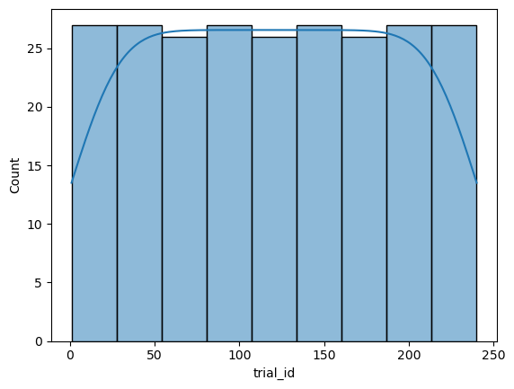

```python
## HISTOGRAMS for NUMERIC COLUNMS
fig,ax = plt.subplots()

sns.histplot(data=df_pj, x='trial_id', ax = ax,kde=True)

plt.show()
```

### Conclusion 1

The categories of the NON_NUMERIC columns : column x3,x4,x6 have similar counts, but column x1,x2,x5 have different counts.

The histograms of the NUMERIC columns: column trial_id doesn't look like bell curve.

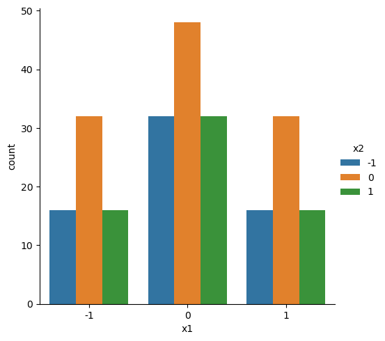

```python
## DODGED BAR PLOT between 2 NON-NUMERIC COLUMNS
sns.catplot(data = df_pj, x = 'x1', hue = 'x2', kind = "count")
plt.show()
```

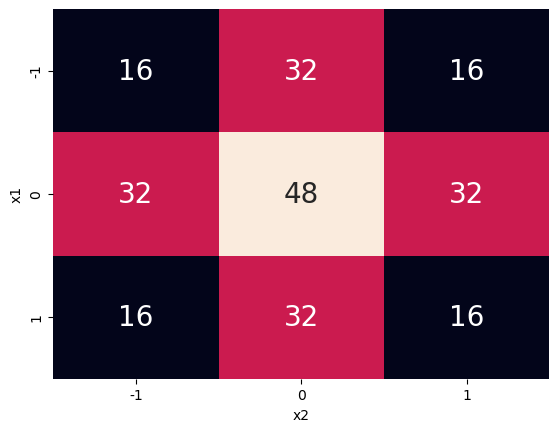

```python
## HEAT MAP between 2 NON-NUMERIC COLUMNS
fig,ax = plt.subplots()

sns.heatmap(pd.crosstab(df_pj['x1'], df_pj['x2']), ax=ax,
            annot = True,
            annot_kws = {'size': 20},
            fmt = 'd',
            cbar = False)

plt.show()
```

### Conclusion 2

No, there are no combinations between the 2 variables NOT present in the data.

HEAT MAP is easier to identify combinations that were NOT present.

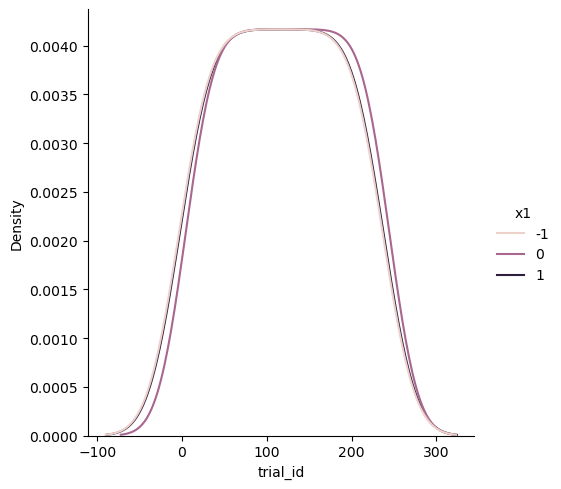

```python
## Conditional KDE PLOT on NUMERIC COLUMN, conditioned on NON-NUMERIC COLUMN
sns.displot(data = df_pj, x = 'trial_id', hue = 'x1', kind = "kde",
            common_norm = False)

plt.show()
```

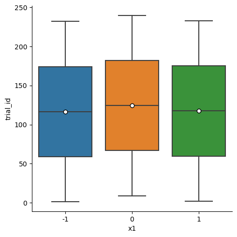

```python
## Boxplot on NUMERIC COLUMN
sns.catplot(data = df_pj, x = 'x1', y = 'trial_id', kind = "box",
            showmeans = True,
            meanprops={'marker':'o','markerfacecolor':'white','markeredgecolor':'black'})

plt.show()
```

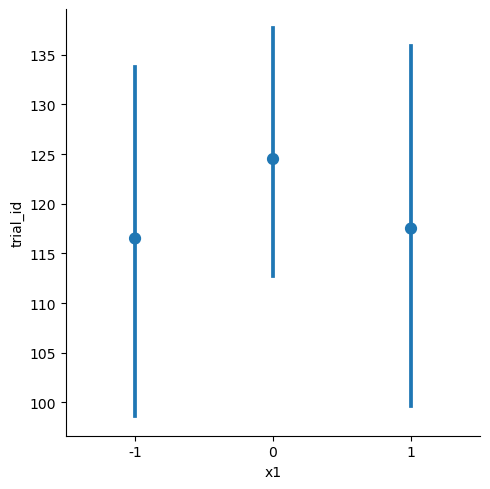

```python
## POINT PLOT on NUMERIC COLUMN
sns.catplot(data = df_pj, x = 'x1', y = 'trial_id', kind = "point",
            join = False)

plt.show()
```

### Conclusion 3

1. No, they are not different.
2. They have similar medians.
3. They have similar variations.
4. No, I am not confident that the MEAN value CHANGES.

## Out Result

```python
df_pj_out = pd.read_csv('./trial_outputs.csv')
df_pj_out.info()
```

```
<class 'pandas.core.frame.DataFrame'>
RangeIndex: 17431 entries, 0 to 17430
Data columns (total 3 columns):
 #   Column    Non-Null Count  Dtype
---  ------    --------------  -----
 0   trial_id  17431 non-null  int64
 1   cycle     17431 non-null  int64
 2   y         17431 non-null  float64
dtypes: float64(1), int64(2)
memory usage: 408.7 KB
```

```python
df_pj_out.nunique()
```

```
trial_id      240
cycle         100
y           17431
dtype: int64
```

```python
## Since there is no NON_NUMERIC columns, we then switch to the next step
```

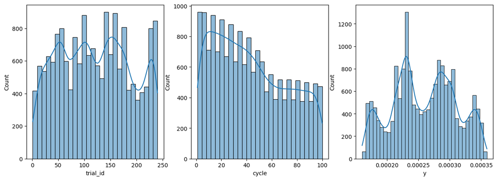

```python
## HISTOGRAMS for NUMERIC COLUNMS
fig,ax = plt.subplots(1,3,figsize=(15,5))

sns.histplot(data=df_pj_out, x='trial_id', ax = ax[0],kde=True)
sns.histplot(data=df_pj_out, x='cycle', ax = ax[1],kde=True)
sns.histplot(data=df_pj_out, x='y', ax = ax[2],kde=True)

plt.show()
```

### Conclusion 1

The histogram of the NUMERIC columns: column trial_id, cycle and y don't look like bell curves.

```python
## DODGED BAR PLOT between 2 NON-NUMERIC COLUMNS

## There is no NON_NUMERIC columns, skip
```

### Conclusion 2

```python
## There is no NON_NUMERIC columns, skip
```

### Conclusion 3

skip